# Analyse des données DVF

## Importation des librairies et des données de Valeur Foncières 2023 depuis le txt dans un dataframe.

```python
import matplotlib.pyplot as plt
import pandas as pd
import numpy as np
import seaborn as sns
from sklearn.model_selection import train_test_split
from sklearn.linear_model import LinearRegression
from sklearn.metrics import mean_squared_error, r2_score
from sklearn.preprocessing import StandardScaler
from sklearn.cluster import KMeans
from pandas.plotting import scatter_matrix
```

```python
df = pd.read_csv('../valeursfoncieres-2023.txt', sep='|', low_memory=False)
```

Premieres visualisation

```python
df.head()
```

|  | Identifiant de document | Reference document | 1 Articles CGI | 2 Articles CGI | 3 Articles CGI | 4 Articles CGI | 5 Articles CGI | No disposition | Date mutation | Nature mutation | ... | Surface Carrez du 5eme lot | Nombre de lots | Code type local | Type local | Identifiant local | Surface reelle bati | Nombre pieces principales | Nature culture | Nature culture speciale | Surface terrain |
| --- | --- | --- | --- | --- | --- | --- | --- | --- | --- | --- | --- | --- | --- | --- | --- | --- | --- | --- | --- | --- | --- |
| 0 | NaN | NaN | NaN | NaN | NaN | NaN | NaN | 1 | 05/01/2023 | Vente | ... | NaN | 1 | 3.0 | Dépendance | NaN | 0.0 | 0.0 | NaN | NaN | NaN |
| 1 | NaN | NaN | NaN | NaN | NaN | NaN | NaN | 1 | 05/01/2023 | Vente | ... | NaN | 1 | 3.0 | Dépendance | NaN | 0.0 | 0.0 | NaN | NaN | NaN |
| 2 | NaN | NaN | NaN | NaN | NaN | NaN | NaN | 1 | 05/01/2023 | Vente | ... | NaN | 1 | 2.0 | Appartement | NaN | 233.0 | 8.0 | NaN | NaN | NaN |
| 3 | NaN | NaN | NaN | NaN | NaN | NaN | NaN | 1 | 03/01/2023 | Vente | ... | NaN | 0 | 1.0 | Maison | NaN | 64.0 | 3.0 | S | NaN | 988.0 |
| 4 | NaN | NaN | NaN | NaN | NaN | NaN | NaN | 1 | 05/01/2023 | Vente | ... | NaN | 0 | 1.0 | Maison | NaN | 73.0 | 3.0 | S | NaN | 835.0 |

5 rows × 43 columns

Visualisation de la forme des données

```python
print(df.shape)
```

```
(3727005, 43)
```

Visualisation de toutes les colonnes

```python
df.columns
```

```
Index(['Identifiant de document', 'Reference document', '1 Articles CGI',
       '2 Articles CGI', '3 Articles CGI', '4 Articles CGI', '5 Articles CGI',
       'No disposition', 'Date mutation', 'Nature mutation', 'Valeur fonciere',
       'No voie', 'B/T/Q', 'Type de voie', 'Code voie', 'Voie', 'Code postal',
       'Commune', 'Code departement', 'Code commune', 'Prefixe de section',
       'Section', 'No plan', 'No Volume', '1er lot',
       'Surface Carrez du 1er lot', '2eme lot', 'Surface Carrez du 2eme lot',
       '3eme lot', 'Surface Carrez du 3eme lot', '4eme lot',
       'Surface Carrez du 4eme lot', '5eme lot', 'Surface Carrez du 5eme lot',
       'Nombre de lots', 'Code type local', 'Type local', 'Identifiant local',
       'Surface reelle bati', 'Nombre pieces principales', 'Nature culture',
       'Nature culture speciale', 'Surface terrain'],
      dtype='object')
```

## Préparation des données:

##### Afficher les colonnes avec 100% de valeurs nulles.

```python
missing_values = df.isnull().sum() /len(df) * 100
missing_values
```

```
Identifiant de document       100.000000
Reference document            100.000000
1 Articles CGI                100.000000
2 Articles CGI                100.000000
3 Articles CGI                100.000000
4 Articles CGI                100.000000
5 Articles CGI                100.000000
No disposition                  0.000000
Date mutation                   0.000000
Nature mutation                 0.000000
Valeur fonciere                 0.868767
No voie                        37.983501
B/T/Q                          95.579024
Type de voie                   40.420981
Code voie                       0.758250
Voie                            0.772551
Code postal                     0.764904
Commune                         0.000000
Code departement                0.000000
Code commune                    0.000000
Prefixe de section             95.379749
Section                         0.004749
No plan                         0.000000
No Volume                      99.778213
1er lot                        69.109218
Surface Carrez du 1er lot      91.143130
2eme lot                       90.342567
Surface Carrez du 2eme lot     97.084603
3eme lot                       98.282321
Surface Carrez du 3eme lot     99.673438
4eme lot                       99.463993
Surface Carrez du 4eme lot     99.924095
5eme lot                       99.773411
Surface Carrez du 5eme lot     99.975288
Nombre de lots                  0.000000
Code type local                42.513063
Type local                     42.513063
Identifiant local             100.000000
Surface reelle bati            42.579363
Nombre pieces principales      42.579363
Nature culture                 31.406371
Nature culture speciale        95.548141
Surface terrain                31.406371
dtype: float64
```

Il y a beaucoup de colonne de valeur entièrement vide

##### Afficher les colonnes avec 100% de valeurs nulles.

```python
missing_values[missing_values == 100]
```

```
Identifiant de document    100.0
Reference document         100.0
1 Articles CGI             100.0
2 Articles CGI             100.0
3 Articles CGI             100.0
4 Articles CGI             100.0
5 Articles CGI             100.0
Identifiant local          100.0
dtype: float64
```

##### Suppression de ces colonnes.

```python
columns_to_drop = missing_values[missing_values == 100].index
df = df.drop(columns=columns_to_drop)
df.head()
```

|  | No disposition | Date mutation | Nature mutation | Valeur fonciere | No voie | B/T/Q | Type de voie | Code voie | Voie | Code postal | ... | 5eme lot | Surface Carrez du 5eme lot | Nombre de lots | Code type local | Type local | Surface reelle bati | Nombre pieces principales | Nature culture | Nature culture speciale | Surface terrain |
| --- | --- | --- | --- | --- | --- | --- | --- | --- | --- | --- | --- | --- | --- | --- | --- | --- | --- | --- | --- | --- | --- |
| 0 | 1 | 05/01/2023 | Vente | 1070000,00 | 184.0 | NaN | ALL | 0124 | DES HETRES | 1630.0 | ... | NaN | NaN | 1 | 3.0 | Dépendance | 0.0 | 0.0 | NaN | NaN | NaN |
| 1 | 1 | 05/01/2023 | Vente | 1070000,00 | 159.0 | NaN | ALL | 0124 | DES HETRES | 1630.0 | ... | NaN | NaN | 1 | 3.0 | Dépendance | 0.0 | 0.0 | NaN | NaN | NaN |
| 2 | 1 | 05/01/2023 | Vente | 1070000,00 | 159.0 | NaN | ALL | 0124 | DES HETRES | 1630.0 | ... | NaN | NaN | 1 | 2.0 | Appartement | 233.0 | 8.0 | NaN | NaN | NaN |
| 3 | 1 | 03/01/2023 | Vente | 152200,00 | 2914.0 | NaN | RTE | 0107 | DE PONCIN | 1450.0 | ... | NaN | NaN | 0 | 1.0 | Maison | 64.0 | 3.0 | S | NaN | 988.0 |
| 4 | 1 | 05/01/2023 | Vente | 269000,00 | 427.0 | T | CHE | 0040 | DE L'AUBEPIN | 1800.0 | ... | NaN | NaN | 0 | 1.0 | Maison | 73.0 | 3.0 | S | NaN | 835.0 |

5 rows × 35 columns

##### Visualisation des colonnes de la nouvelle dataframe.

```python
df.columns
```

```
Index(['No disposition', 'Date mutation', 'Nature mutation', 'Valeur fonciere',
       'No voie', 'B/T/Q', 'Type de voie', 'Code voie', 'Voie', 'Code postal',
       'Commune', 'Code departement', 'Code commune', 'Prefixe de section',
       'Section', 'No plan', 'No Volume', '1er lot',
       'Surface Carrez du 1er lot', '2eme lot', 'Surface Carrez du 2eme lot',
       '3eme lot', 'Surface Carrez du 3eme lot', '4eme lot',
       'Surface Carrez du 4eme lot', '5eme lot', 'Surface Carrez du 5eme lot',
       'Nombre de lots', 'Code type local', 'Type local',
       'Surface reelle bati', 'Nombre pieces principales', 'Nature culture',
       'Nature culture speciale', 'Surface terrain'],
      dtype='object')
```

##### Tri des colonnes qui ne seront pas utiles à notre analyse.

Ce qu'on ne garde pas :

- 'Date mutation'
- 'Commune'
- 'Nature mutation'
- 'Nature culture speciale'
- 'No disposition'
- 'No voie'
- 'No plan'
- 'No Volume'
- 'Nombre de lots'
- 'Voie'
- 'Type local'
- 'Type de voie'
- 'Surface Carrez du 2/3/4/5eme lot'
- 'Section'
- '2/3/4eme lot'
- 'Prefixe de section'
- 'B/T/Q'

Ce qu'on garde :

- 'Surface Carrez du 1er lot'
- '1er lot'
- 'Code voie'
- 'Code postal'
- 'Code departement'
- 'Code commune'
- 'Code type local'
- 'Surface reelle bati'
- 'Nombre pieces principales'
- 'Nature culture'
- 'Surface terrain'
- 'Valeur fonciere'

Nous gardons ces colonnes car nous priorisons les valeurs numériques au colonnes de texte. Egalement, la répartition des terrains en lots ne nous intéresse pas, sauf la premiere. Nous faisons une analyse sur l'année, aussi la date de mutation ne nous est pas utile. D'autres colonnes à caractères trop spécifiques sont également mises de côté.

```python
columns = ['B/T/Q', 'Prefixe de section', 'No Volume', '2eme lot', 'Surface Carrez du 2eme lot', '3eme lot',
           'Surface Carrez du 3eme lot', '4eme lot', 'Surface Carrez du 4eme lot', '5eme lot',
           'Surface Carrez du 5eme lot']
df.drop(columns, axis=1, inplace=True)
df.head()
```

|  | No disposition | Date mutation | Nature mutation | Valeur fonciere | No voie | Type de voie | Code voie | Voie | Code postal | Commune | ... | 1er lot | Surface Carrez du 1er lot | Nombre de lots | Code type local | Type local | Surface reelle bati | Nombre pieces principales | Nature culture | Nature culture speciale | Surface terrain |
| --- | --- | --- | --- | --- | --- | --- | --- | --- | --- | --- | --- | --- | --- | --- | --- | --- | --- | --- | --- | --- | --- |
| 0 | 1 | 05/01/2023 | Vente | 1070000,00 | 184.0 | ALL | 0124 | DES HETRES | 1630.0 | ST-GENIS-POUILLY | ... | 29 | NaN | 1 | 3.0 | Dépendance | 0.0 | 0.0 | NaN | NaN | NaN |
| 1 | 1 | 05/01/2023 | Vente | 1070000,00 | 159.0 | ALL | 0124 | DES HETRES | 1630.0 | ST-GENIS-POUILLY | ... | 8 | NaN | 1 | 3.0 | Dépendance | 0.0 | 0.0 | NaN | NaN | NaN |
| 2 | 1 | 05/01/2023 | Vente | 1070000,00 | 159.0 | ALL | 0124 | DES HETRES | 1630.0 | ST-GENIS-POUILLY | ... | 22 | NaN | 1 | 2.0 | Appartement | 233.0 | 8.0 | NaN | NaN | NaN |
| 3 | 1 | 03/01/2023 | Vente | 152200,00 | 2914.0 | RTE | 0107 | DE PONCIN | 1450.0 | SERRIERES-SUR-AIN | ... | NaN | NaN | 0 | 1.0 | Maison | 64.0 | 3.0 | S | NaN | 988.0 |
| 4 | 1 | 05/01/2023 | Vente | 269000,00 | 427.0 | CHE | 0040 | DE L'AUBEPIN | 1800.0 | SAINT-JEAN-DE-NIOST | ... | NaN | NaN | 0 | 1.0 | Maison | 73.0 | 3.0 | S | NaN | 835.0 |

5 rows × 24 columns

```python
df.drop(['Nature culture speciale'], axis=1, inplace=True)
```

```python
columns = ['Code postal', 'Commune', 'Nature mutation', 'Date mutation', 'Type local', 'Voie', 'No disposition', 'No plan', 'Section']
df.drop(columns, axis=1, inplace=True)
df.head()
```

|  | Valeur fonciere | No voie | Type de voie | Code voie | Code departement | Code commune | 1er lot | Surface Carrez du 1er lot | Nombre de lots | Code type local | Surface reelle bati | Nombre pieces principales | Nature culture | Surface terrain |
| --- | --- | --- | --- | --- | --- | --- | --- | --- | --- | --- | --- | --- | --- | --- |
| 0 | 1070000,00 | 184.0 | ALL | 0124 | 01 | 354 | 29 | NaN | 1 | 3.0 | 0.0 | 0.0 | NaN | NaN |
| 1 | 1070000,00 | 159.0 | ALL | 0124 | 01 | 354 | 8 | NaN | 1 | 3.0 | 0.0 | 0.0 | NaN | NaN |
| 2 | 1070000,00 | 159.0 | ALL | 0124 | 01 | 354 | 22 | NaN | 1 | 2.0 | 233.0 | 8.0 | NaN | NaN |
| 3 | 152200,00 | 2914.0 | RTE | 0107 | 01 | 404 | NaN | NaN | 0 | 1.0 | 64.0 | 3.0 | S | 988.0 |
| 4 | 269000,00 | 427.0 | CHE | 0040 | 01 | 361 | NaN | NaN | 0 | 1.0 | 73.0 | 3.0 | S | 835.0 |

##### Visualisation du pourcentage de valeur nulles dans les datas finales.

```python
(df.isnull().sum() / len(df)) * 100
```

```
Valeur fonciere               0.868767
No voie                      37.983501
Type de voie                 40.420981
Code voie                     0.758250
Code departement              0.000000
Code commune                  0.000000
1er lot                      69.109218
Surface Carrez du 1er lot    91.143130
Nombre de lots                0.000000
Code type local              42.513063
Surface reelle bati          42.579363
Nombre pieces principales    42.579363
Nature culture               31.406371
Surface terrain              31.406371
dtype: float64
```

```python
df.info()
```

```
<class 'pandas.core.frame.DataFrame'>
RangeIndex: 3727005 entries, 0 to 3727004
Data columns (total 14 columns):
 #   Column                     Dtype
---  ------                     -----
 0   Valeur fonciere            object
 1   No voie                    float64
 2   Type de voie               object
 3   Code voie                  object
 4   Code departement           object
 5   Code commune               int64
 6   1er lot                    object
 7   Surface Carrez du 1er lot  object
 8   Nombre de lots             int64
 9   Code type local            float64
 10  Surface reelle bati        float64
 11  Nombre pieces principales  float64
 12  Nature culture             object
 13  Surface terrain            float64
dtypes: float64(5), int64(2), object(7)
memory usage: 398.1+ MB
```

##### Changement des types des variables 'Valeur fonciere' et 'Surface Carrez du 1er lot'

les floats python comportent des '.' et non des ','

```python
df['Valeur fonciere'] = df['Valeur fonciere'].str.replace(',', '.')
df['Surface Carrez du 1er lot'] = df['Surface Carrez du 1er lot'].str.replace(',', '.')
```

Maintenant, on peut les mettre en 'float'

```python
df['Valeur fonciere'] = df['Valeur fonciere'].astype(float)
df['Surface Carrez du 1er lot'] = df['Surface Carrez du 1er lot'].astype(float)
```

##### Remplacement des valeurs textuelles de la colonne "Nature culture" en valeur numériques.

```python
df['Nature culture'].replace({
    "AB": 0, # terrins à batir
    "AG": 0, #terrain d'agrément
    "B": 1, #bois
    "BF": 1, #futaies feuilues
    "BM": 1, #futaies mixtes
    "BO": 1, # oseraies
    "BP": 1, #peupleraies
    "BR": 1, #futaies résineuses
    "BS": 1, #taillis sous futaies
    "BT": 1, #taillis simples
    "CA": 2, #carrières
    "CH": 2, #chemin de fer
    "E": 3, #eau
    "J": 4, #jardins
    "L": 5, #landes
    "LB": 5, #landes boisées
    "P": 6, #prés
    "PA": 6, #patures
    "PC": 6, # pacages
    "PE": 6, #prés d'embouche
    "PH": 6, #herbage
    "PP": 6, #prés plantes
    "S": 7, #sol
    "T": 8, #terres
    "TP": 8, #terres plantées
    "VE": 9, #vergers
    "VI": 9 #vignes
}, inplace=True)
```

##### Calcul du prix au m2 en utilisant la valeur foncière divisée par la surface réelle bâtie.

```python
df['Prix au mètre carré'] = df['Valeur fonciere'] / df['Surface reelle bati']
df = df.replace([float('inf'), -float('inf')], np.nan)
```

```python
df.head()
```

|  | Valeur fonciere | No voie | Type de voie | Code voie | Code departement | Code commune | 1er lot | Surface Carrez du 1er lot | Nombre de lots | Code type local | Surface reelle bati | Nombre pieces principales | Nature culture | Surface terrain | Prix au mètre carré |
| --- | --- | --- | --- | --- | --- | --- | --- | --- | --- | --- | --- | --- | --- | --- | --- |
| 0 | 1070000.0 | 184.0 | ALL | 0124 | 01 | 354 | 29 | NaN | 1 | 3.0 | 0.0 | 0.0 | NaN | NaN | NaN |
| 1 | 1070000.0 | 159.0 | ALL | 0124 | 01 | 354 | 8 | NaN | 1 | 3.0 | 0.0 | 0.0 | NaN | NaN | NaN |
| 2 | 1070000.0 | 159.0 | ALL | 0124 | 01 | 354 | 22 | NaN | 1 | 2.0 | 233.0 | 8.0 | NaN | NaN | 4592.274678 |
| 3 | 152200.0 | 2914.0 | RTE | 0107 | 01 | 404 | NaN | NaN | 0 | 1.0 | 64.0 | 3.0 | 7.0 | 988.0 | 2378.125000 |
| 4 | 269000.0 | 427.0 | CHE | 0040 | 01 | 361 | NaN | NaN | 0 | 1.0 | 73.0 | 3.0 | 7.0 | 835.0 | 3684.931507 |

##### Création et sauvegarde du nouveau dataframe dans le fichier : 'df_clean.txt'.

```python
df.to_csv('df_clean.txt', sep='|', index=False, encoding='utf-8')
```

```python
df = pd.read_csv("df_clean.txt", sep='|', low_memory=False)
```

Nettoyage des valeurs nulles de la colonne 'Valeur froncière'

```python
df_new = df.dropna(subset=['Valeur fonciere'])
```

##### Création de 'df_map' pour transformer les colonnes 'objet' en 'int'

```python
columns = ['Valeur fonciere', 'No voie', 'Code commune', 'Surface Carrez du 1er lot', 'Nombre de lots',
           'Code type local', 'Surface reelle bati', 'Nombre pieces principales', 'Surface terrain',
           'Prix au mètre carré']
df_map = df_new.copy()

for col in df_new.columns:
    if df_new[col].dtype == object:
        df_map.loc[:, col] = pd.factorize(df_map[col])[0]
        df_map[col] = df_map[col].astype(int)
df_map
```

|  | Valeur fonciere | No voie | Type de voie | Code voie | Code departement | Code commune | 1er lot | Surface Carrez du 1er lot | Nombre de lots | Code type local | Surface reelle bati | Nombre pieces principales | Nature culture | Surface terrain | Prix au mètre carré |
| --- | --- | --- | --- | --- | --- | --- | --- | --- | --- | --- | --- | --- | --- | --- | --- |
| 0 | 1070000.0 | 184.0 | 0 | 0 | 0 | 354 | 0 | NaN | 1 | 3.0 | 0.0 | 0.0 | NaN | NaN | NaN |
| 1 | 1070000.0 | 159.0 | 0 | 0 | 0 | 354 | 1 | NaN | 1 | 3.0 | 0.0 | 0.0 | NaN | NaN | NaN |
| 2 | 1070000.0 | 159.0 | 0 | 0 | 0 | 354 | 2 | NaN | 1 | 2.0 | 233.0 | 8.0 | NaN | NaN | 4592.274678 |
| 3 | 152200.0 | 2914.0 | 1 | 1 | 0 | 404 | -1 | NaN | 0 | 1.0 | 64.0 | 3.0 | 7.0 | 988.0 | 2378.125000 |
| 4 | 269000.0 | 427.0 | 2 | 2 | 0 | 361 | -1 | NaN | 0 | 1.0 | 73.0 | 3.0 | 7.0 | 835.0 | 3684.931507 |
| ... | ... | ... | ... | ... | ... | ... | ... | ... | ... | ... | ... | ... | ... | ... | ... |
| 3727000 | 3931000.0 | 39.0 | 4 | 2201 | 96 | 107 | 10 | NaN | 1 | 3.0 | 0.0 | 0.0 | NaN | NaN | NaN |
| 3727001 | 3931000.0 | 39.0 | 4 | 2201 | 96 | 107 | 99 | NaN | 1 | 3.0 | 0.0 | 0.0 | NaN | NaN | NaN |
| 3727002 | 3931000.0 | 39.0 | 4 | 2201 | 96 | 107 | 27 | NaN | 1 | 3.0 | 0.0 | 0.0 | NaN | NaN | NaN |
| 3727003 | 98250.0 | 66.0 | 3 | 11163 | 96 | 115 | 132 | NaN | 1 | 3.0 | 0.0 | 0.0 | NaN | NaN | NaN |
| 3727004 | 98250.0 | 66.0 | 3 | 11163 | 96 | 115 | 132 | NaN | 1 | 2.0 | 18.0 | 1.0 | NaN | NaN | 5458.333333 |

3694626 rows × 15 columns

```python
df_new.info()
```

```
<class 'pandas.core.frame.DataFrame'>
Index: 3694626 entries, 0 to 3727004
Data columns (total 15 columns):
 #   Column                     Dtype
---  ------                     -----
 0   Valeur fonciere            float64
 1   No voie                    float64
 2   Type de voie               object
 3   Code voie                  object
 4   Code departement           object
 5   Code commune               int64
 6   1er lot                    object
 7   Surface Carrez du 1er lot  float64
 8   Nombre de lots             int64
 9   Code type local            float64
 10  Surface reelle bati        float64
 11  Nombre pieces principales  float64
 12  Nature culture             float64
 13  Surface terrain            float64
 14  Prix au mètre carré        float64
dtypes: float64(9), int64(2), object(4)
memory usage: 451.0+ MB
```

```python
df_map.info()
```

```
<class 'pandas.core.frame.DataFrame'>
Index: 3694626 entries, 0 to 3727004
Data columns (total 15 columns):
 #   Column                     Dtype
---  ------                     -----
 0   Valeur fonciere            float64
 1   No voie                    float64
 2   Type de voie               int64
 3   Code voie                  int64
 4   Code departement           int64
 5   Code commune               int64
 6   1er lot                    int64
 7   Surface Carrez du 1er lot  float64
 8   Nombre de lots             int64
 9   Code type local            float64
 10  Surface reelle bati        float64
 11  Nombre pieces principales  float64
 12  Nature culture             float64
 13  Surface terrain            float64
 14  Prix au mètre carré        float64
dtypes: float64(9), int64(6)
memory usage: 451.0 MB
```

## Analyse exploratoire des données:

##### Affichage de la répartition des différentes nature de culture.

[figure not shown]

```python
# Dictionnaire de correspondance
mapping = {7: 'S', 8: 'T', 6: 'P', 1: 'J', 0: 'BT', 4: 'L', 5: 'AB', 9: 'AG'}

seuil_minimal = 2 #pour ne pas voir les proportions inférieures à 2% (négligeable)
nature_culture_counts = df['Nature culture'].value_counts()
total = nature_culture_counts.sum()
pourcentages = (nature_culture_counts / total) * 100
catégories_filtrées = pourcentages[pourcentages >= seuil_minimal].index
nature_culture_filtrée = df[df['Nature culture'].isin(catégories_filtrées)]['Nature culture'].value_counts()

# Mise à jour des labels de la légende
labels = ["{}: {:.2f}%".format(mapping.get(int(label), label), (nature_culture_filtrée[label] / total) * 100) for label in nature_culture_filtrée.index]

nature_culture_filtrée.plot(kind='pie', labels=None)
plt.title('Répartition de la nature de la culture')
plt.legend(labels=labels, loc='upper right')
plt.axis('equal')
plt.show()
```

##### Etude de la répartition des types de nature de culture des terrains qui comportent un bâtiment (code type local).

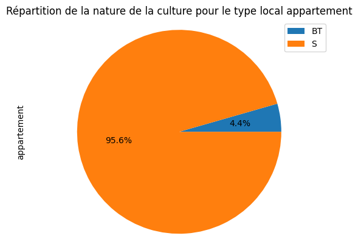

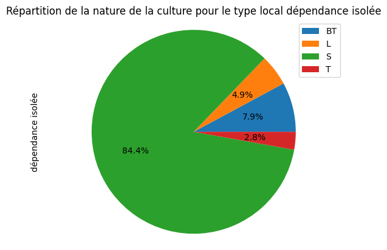

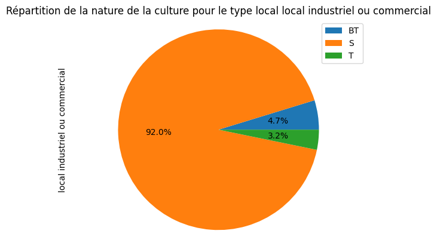

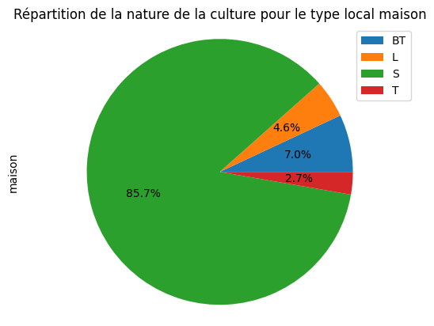

```python
type_local_mapping = {
    1: 'maison',
    2: 'appartement',
    3: 'dépendance isolée',
    4: 'local industriel ou commercial'
}
df['Type local'] = df['Code type local'].map(type_local_mapping)

# Dictionnaire de correspondance pour 'Nature culture'
nature_culture_mapping = {7: 'S', 8: 'T', 6: 'P', 1: 'J', 0: 'BT', 4: 'L', 5: 'AB', 9: 'AG'}
df['Nature culture'] = df['Nature culture'].map(nature_culture_mapping)

seuil_minimal = 2 #pour ne pas voir les proportions inférieures à 2% (négligeable)
pivot_table = df.pivot_table(index='Nature culture', columns='Type local', aggfunc='size', fill_value=0)
pivot_table_percent = pivot_table.div(pivot_table.sum(axis=0), axis=1) * 100

for col in pivot_table_percent.columns:
    filtered_data = pivot_table_percent[col][pivot_table_percent[col] >= seuil_minimal]
    if filtered_data.sum() > 0:
        filtered_data.plot(kind='pie', labels=None, autopct='%1.1f%%')
        plt.title(f'Répartition de la nature de la culture pour le type local {col}')
        plt.legend(labels=filtered_data.index, loc='upper right')
        plt.axis('equal')
        plt.show()
```

- Nous pouvons voir que le sol représente ~90% des terrains où un bâtiment se trouve.
- Nous pouvons donc en déduire que l'importante proportion des terrains de type "Sol" provient en partie du fait que ce soit le type de la plupart des terrains construits.

##### Affichage du graphe du code département en fonction du prix au m^2.

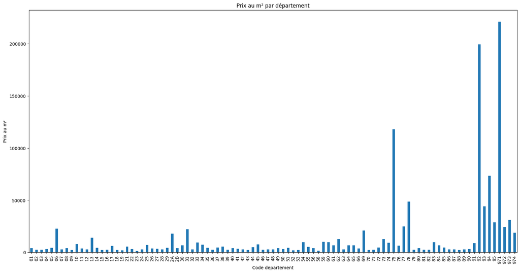

```python
df_new.groupby('Code departement')['Prix au mètre carré'].mean().plot(kind='bar', figsize=(20, 10))
plt.ylabel('Prix au m²')
plt.title('Prix au m² par département')
plt.show()
```

Nous remarquons que les départements 92 et 971 semblent montrer des valeurs trop hautes comparées à la réalité. Ceci doit être dû à des valeurs absurdes que nous devons nettoyer.

Calcul du prix moyen au mètre carré des deux départements problématiques

```python
prixMoyen = df_new.groupby('Code departement')['Prix au mètre carré'].mean().reset_index()
prixMoyen[(prixMoyen['Code departement'] == '92') | (prixMoyen['Code departement'] == '971')]
```

|  | Code departement | Prix au mètre carré |
| --- | --- | --- |
| 89 | 92 | 199536.921051 |
| 93 | 971 | 221163.558183 |

Visualisation des valeurs moyennes

```python
Dep92 = df_new[(df_new['Code departement'] == '92')]
Dep971 = df_new[(df_new['Code departement'] == '971')]
```

```
Pour le département 92 :
```

```python
Dep92[(Dep92['Prix au mètre carré'] >= 0.5e7)]
```

|  | Valeur fonciere | No voie | Type de voie | Code voie | Code departement | Code commune | 1er lot | Surface Carrez du 1er lot | Nombre de lots | Code type local | Surface reelle bati | Nombre pieces principales | Nature culture | Surface terrain | Prix au mètre carré |
| --- | --- | --- | --- | --- | --- | --- | --- | --- | --- | --- | --- | --- | --- | --- | --- |
| 3425901 | 64032852.0 | 11.0 | QUAI | 2547 | 92 | 62 | 160 | NaN | 1 | 4.0 | 3.0 | 0.0 | NaN | NaN | 21344284.0 |
| 3425902 | 64032852.0 | 11.0 | QUAI | 2547 | 92 | 62 | 159 | NaN | 1 | 4.0 | 3.0 | 0.0 | NaN | NaN | 21344284.0 |
| 3425906 | 64032852.0 | 11.0 | QUAI | 2547 | 92 | 62 | 333 | NaN | 1 | 4.0 | 3.0 | 0.0 | NaN | NaN | 21344284.0 |
| 3425914 | 64032852.0 | 11.0 | QUAI | 2547 | 92 | 62 | 300 | NaN | 1 | 4.0 | 3.0 | 0.0 | NaN | NaN | 21344284.0 |
| 3425915 | 64032852.0 | 11.0 | QUAI | 2547 | 92 | 62 | 377 | NaN | 1 | 4.0 | 3.0 | 0.0 | NaN | NaN | 21344284.0 |
| ... | ... | ... | ... | ... | ... | ... | ... | ... | ... | ... | ... | ... | ... | ... | ... |
| 3426096 | 64032852.0 | 11.0 | QUAI | 2547 | 92 | 62 | 320 | NaN | 1 | 4.0 | 3.0 | 0.0 | NaN | NaN | 21344284.0 |
| 3426097 | 64032852.0 | 11.0 | QUAI | 2547 | 92 | 62 | 112 | NaN | 1 | 4.0 | 3.0 | 0.0 | NaN | NaN | 21344284.0 |
| 3426098 | 64032852.0 | 11.0 | QUAI | 2547 | 92 | 62 | 319 | NaN | 1 | 4.0 | 3.0 | 0.0 | NaN | NaN | 21344284.0 |
| 3439886 | 75000000.0 | 23.0 | AV | 4165 | 92 | 73 | NaN | NaN | 0 | 4.0 | 10.0 | 0.0 | 7.0 | 1179.0 | 7500000.0 |
| 3440045 | 75000000.0 | 23.0 | AV | 4165 | 92 | 73 | NaN | NaN | 0 | 4.0 | 15.0 | 0.0 | 7.0 | 1179.0 | 5000000.0 |

165 rows × 15 columns

Il y a beaucoup de données qui semblent fausses par leurs valeurs trop hautes. Nous choisissons de les supprimer pour aider à obtenir de resultats plus cohérents

Création d'une copie de df_new

```python
df_new_bis = df_new.copy()
```

```python
indices_a_supprimer = Dep92[(Dep92['Prix au mètre carré'] >= 0.5e7)].index
df_new_bis.drop(indices_a_supprimer, inplace=True)
```

```
Pour le département 971 :
```

```python
Dep971[(Dep971['Prix au mètre carré'] >= 0.5e6)]
```

|  | Valeur fonciere | No voie | Type de voie | Code voie | Code departement | Code commune | 1er lot | Surface Carrez du 1er lot | Nombre de lots | Code type local | Surface reelle bati | Nombre pieces principales | Nature culture | Surface terrain | Prix au mètre carré |
| --- | --- | --- | --- | --- | --- | --- | --- | --- | --- | --- | --- | --- | --- | --- | --- |
| 3616442 | 30000000.0 | 101.0 | CITE | A700 | 971 | 1 | NaN | NaN | 0 | 2.0 | 40.0 | 2.0 | 7.0 | 2141.0 | 750000.000000 |
| 3616443 | 30000000.0 | 101.0 | CITE | A700 | 971 | 1 | NaN | NaN | 0 | 2.0 | 49.0 | 3.0 | 7.0 | 2141.0 | 612244.897959 |
| 3616444 | 30000000.0 | 101.0 | CITE | A700 | 971 | 1 | NaN | NaN | 0 | 2.0 | 40.0 | 2.0 | 7.0 | 2141.0 | 750000.000000 |
| 3616445 | 30000000.0 | 101.0 | CITE | A700 | 971 | 1 | NaN | NaN | 0 | 2.0 | 49.0 | 3.0 | 7.0 | 2141.0 | 612244.897959 |
| 3616446 | 30000000.0 | 101.0 | CITE | A700 | 971 | 1 | NaN | NaN | 0 | 2.0 | 40.0 | 2.0 | 7.0 | 2141.0 | 750000.000000 |
| ... | ... | ... | ... | ... | ... | ... | ... | ... | ... | ... | ... | ... | ... | ... | ... |
| 3618118 | 30000000.0 | 9001.0 | RES | A085 | 971 | 20 | NaN | NaN | 0 | 2.0 | 54.0 | 4.0 | 7.0 | 258.0 | 555555.555556 |
| 3618119 | 30000000.0 | 9001.0 | RES | A085 | 971 | 20 | NaN | NaN | 0 | 2.0 | 54.0 | 4.0 | 7.0 | 258.0 | 555555.555556 |
| 3618120 | 30000000.0 | 9001.0 | RES | A085 | 971 | 20 | NaN | NaN | 0 | 2.0 | 41.0 | 3.0 | 7.0 | 258.0 | 731707.317073 |
| 3618121 | 30000000.0 | 9001.0 | RES | A085 | 971 | 20 | NaN | NaN | 0 | 2.0 | 54.0 | 4.0 | 7.0 | 258.0 | 555555.555556 |
| 3618122 | 30000000.0 | 9001.0 | RES | A085 | 971 | 20 | NaN | NaN | 0 | 2.0 | 54.0 | 4.0 | 7.0 | 258.0 | 555555.555556 |

1612 rows × 15 columns

meme chose, nous supprimons les lignes invraisemblables

```python
indices_a_supprimer = Dep971[Dep971['Prix au mètre carré'] >= 0.5e6].index
df_new_bis.drop(indices_a_supprimer, inplace=True)
```

```python
df_new = df_new_bis
```

##### Affichage du graphe modifié, qui est cohérent à présent.

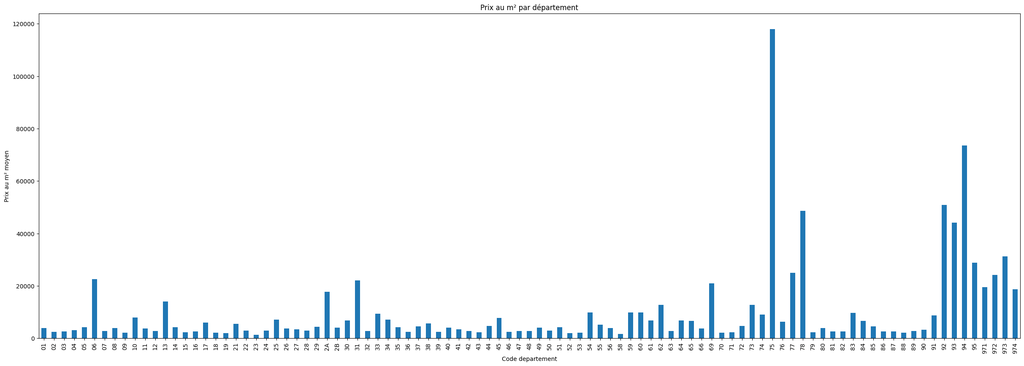

```python
df_new.groupby('Code departement')['Prix au mètre carré'].mean().plot(kind='bar', figsize=(30, 10))
plt.ylabel('Prix au m² moyen')
plt.title('Prix au m² par département')
plt.show()
```

##### Calcul le prix maximun et du prix moyen au m² du departement 75 (Paris) qui est le plus haut

```python
infoDep75 = df_new[(df_new['Code departement'] == '75')]
prixMax = infoDep75['Prix au mètre carré'].max()
print("\nPrix maximal au m² dans le 75 : ", prixMax)
prixMoyen = infoDep75['Prix au mètre carré'].mean()
print("Prix moyen au m² dans le 75 : ", prixMoyen)
```

```
Prix maximal au m² dans le 75 :  95250000.0
Prix moyen au m² dans le 75 :  117966.40444447006
```

- Paris est le département qui a le prix au m^2 le plus élevé, ce qui est cohérent avec le marché immobilier parisien connu pour être très coûteux.
- Ces départements autour de Paris montrent également des prix élevés, reflétant la proximité avec la capitale et la demande élevée.
- Le département 69 (Rhône) est un autre pic important, représentant probablement Lyon, une autre grande ville avec des prix immobiliers élevés.

##### Affichage du prix au m2 moyen en fonction du type de local.

Il est notable que les locaux industriels valent plus au m2 que les autres types. Les appartement sont ensuite les plus coûteux.

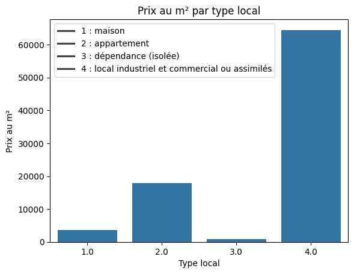

```python
grouped_data = df_new.groupby('Code type local')['Prix au mètre carré'].mean().reset_index()
sns.barplot(x='Code type local', y='Prix au mètre carré', data=grouped_data )
plt.ylabel('Prix au m²')
plt.xlabel('Type local')
plt.legend(['1 : maison', '2 : appartement', '3 : dépendance (isolée)', '4 : local industriel et commercial ou assimilés'])
plt.title('Prix au m² par type local')
plt.show()
```

##### Calculs des moyennes du prix au m^2 par type de local :

```python
print('Prix moyen au m² des maisons :', df_new[df_new['Code type local'] == 1]['Prix au mètre carré'].mean())
print('Prix moyen au m² des appartements :', df_new[df_new['Code type local'] == 2]['Prix au mètre carré'].mean())
print('Prix moyen au m² des dépendances (isolées) :', df_new[df_new['Code type local'] == 3]['Prix au mètre carré'].mean())
print('Prix moyen au m² des locaux industriels et commerciaux ou assimilés :', df_new[df_new['Code type local'] == 4]['Prix au mètre carré'].mean())
```

```
Prix moyen au m² des maisons : 3548.632548446072
Prix moyen au m² des appartements : 17809.06121125161
Prix moyen au m² des dépendances (isolées) : 937.5
Prix moyen au m² des locaux industriels et commerciaux ou assimilés : 64462.92515602612
```

- Pour les maison : Le prix au m² pour les maisons est relativement bas.
- Les appartements ont un prix au m² plus élevé, ce qui est typique des biens immobiliers en milieu urbain.
- Les locaux affichent le prix au m² le plus élevé. Cela reflète la valeur élevée des espaces commerciaux et industriels, souvent situés dans des zones stratégiques avec une demande élevée.

##### Affichage du prix au m2 moyen en fonction de la nature de culture.

Il est notable que les eaux valent beaucoup, mais qu'au contraire les carrières et chemins de fer sont peu coûteux.

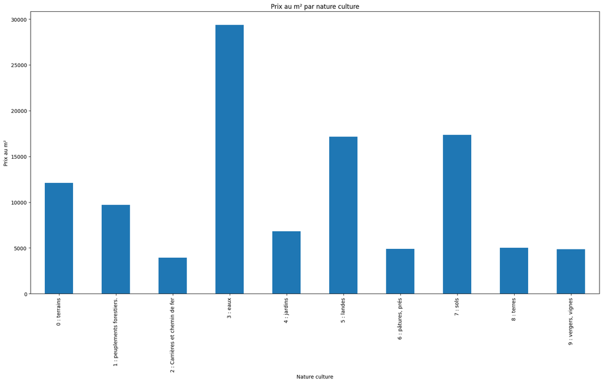

```python
df_new.groupby('Nature culture')['Prix au mètre carré'].mean().plot(kind='bar', figsize=(20, 10))
plt.xlabel('Nature culture')
plt.ylabel('Prix au m²')
labels = [ '0 : terrains', '1 : peuplements forestiers.', '2 : Carrières et chemin de fer', '3 : eaux', '4 : jardins', '5 : landes', '6 : pâtures, prés', '7 : sols', '8 : terres', '9 : vergers, vignes']
plt.xticks(range(len(labels)), labels, rotation='vertical')
plt.title('Prix au m² par nature culture')
plt.show()
```

##### Affichage du nombre de pièces principales moyennes par type de local (maisons, appartement, dépendance ou local industriel/commercial).

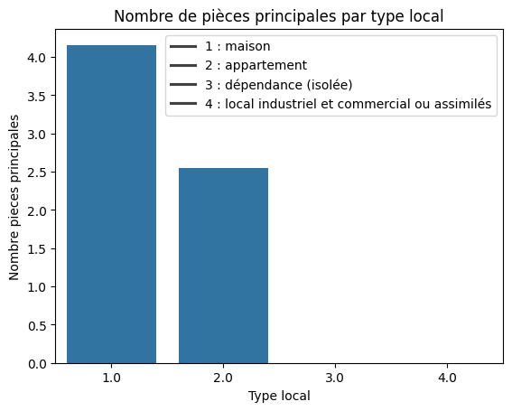

```python
grouped_data = df_new.groupby('Code type local')['Nombre pieces principales'].mean().reset_index()
sns.barplot(x='Code type local', y='Nombre pieces principales', data=grouped_data )
plt.ylabel('Nombre pieces principales')
plt.xlabel('Type local')
plt.legend(['1 : maison', '2 : appartement', '3 : dépendance (isolée)', '4 : local industriel et commercial ou assimilés'])
plt.title('Nombre de pièces principales par type local')
plt.show()
```

- Les maisons ont en moyenne un peu plus de 4 pièces principales, ce qui est cohérent avec les maisons familiales ayant plusieurs chambres, un salon, une cuisine, etc.
- Les appartements ont en moyenne un peu moins de 3 pièces principales, ce qui correspond généralement à des configurations de type T2 (une chambre, un salon) ou T3 (deux chambres, un salon).
- Les dépendances (telles que cave, garage, cellier isolés) ne comportent pas de pièces principales.
- Egalement, les locaux industriels et commerciaux ou assimilés ne sont pas considérés comme comportant des pièces principales.

##### Matrice de corrélation

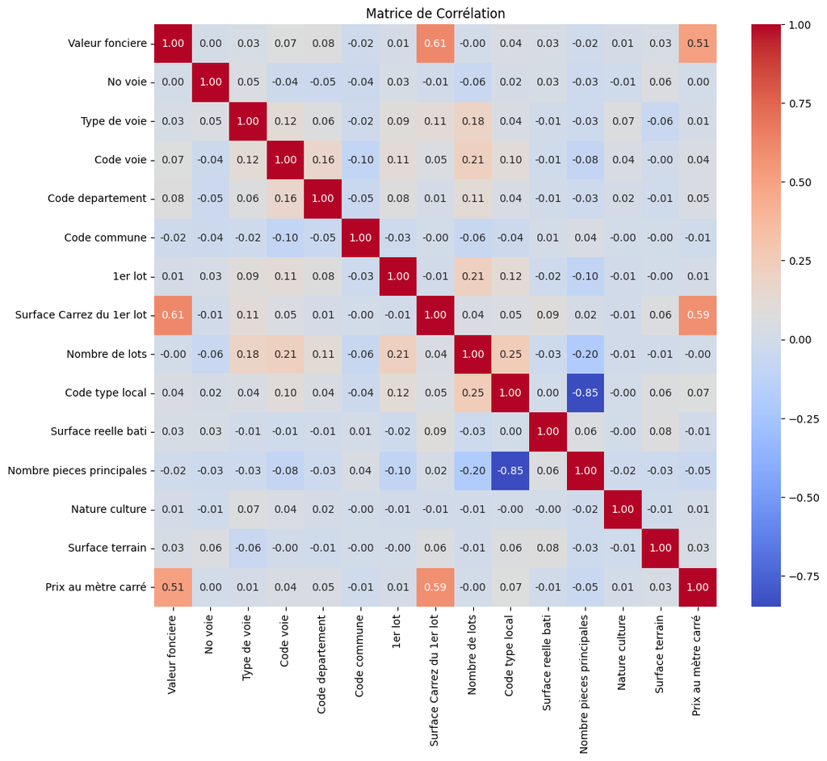

```python
corr_matrix = df_map.corr()

plt.figure(figsize=(12, 10))
sns.heatmap(corr_matrix, annot=True, fmt='.2f', cmap='coolwarm', cbar=True)
plt.title('Matrice de Corrélation')
plt.show()
```

# Apprentissage Non-Supervisé

```
Kmeans
```

```python
df_filtered = df_new[['Prix au mètre carré', 'Code departement', 'Surface reelle bati']].dropna()
df_filtered = df_filtered[(df_filtered['Prix au mètre carré'] < 50000) & (df_filtered['Surface reelle bati'] < 500)]
```

Standardiser les données

```python
scaler = StandardScaler()
df_scaled = scaler.fit_transform(df_filtered[['Prix au mètre carré', 'Surface reelle bati']])
```

Détermination du nombre optimal de clusters avec la méthode du coude

```python
wcss = []
for i in range(1, 11):
    kmeans = KMeans(n_clusters=i, random_state=42)
    kmeans.fit(df_scaled)
    wcss.append(kmeans.inertia_)
```

Méthode du coude :

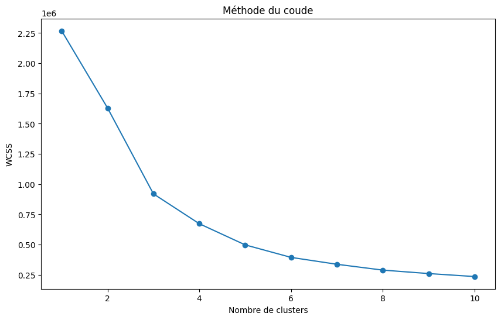

```python
plt.figure(figsize=(10, 6))
plt.plot(range(1, 11), wcss, marker='o')
plt.title('Méthode du coude')
plt.xlabel('Nombre de clusters')
plt.ylabel('WCSS')
plt.show()
```

Choisir le nombre de clusters (3)

```python
kmeans = KMeans(n_clusters=3, random_state=42)
df_filtered['Cluster'] = kmeans.fit_predict(df_scaled)
```

Visualiser les clusters

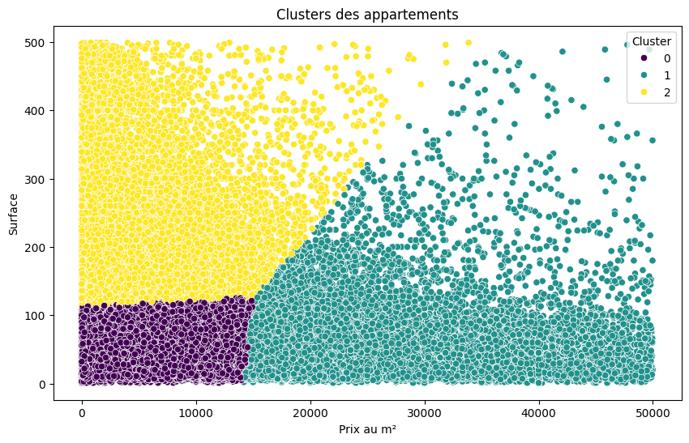

```
Cluster 2:
       Prix au mètre carré  Surface reelle bati   Cluster
count        209877.000000        209877.000000  209877.0
mean           2613.652759           165.522315       2.0
std            2340.825459            62.215644       0.0
min               0.000357           113.000000       2.0
25%            1250.000000           127.000000       2.0
50%            2023.076923           144.000000       2.0
75%            3157.894737           178.000000       2.0
max           33867.735471           499.000000       2.0
Cluster 0:
       Prix au mètre carré  Surface reelle bati   Cluster
count        881553.000000        881553.000000  881553.0
mean           3496.975162            65.958709       0.0
std            2656.857023            25.852020       0.0
min               0.001500             1.000000       0.0
25%            1722.222222            45.000000       0.0
50%            2761.194030            67.000000       0.0
75%            4411.764706            86.000000       0.0
max           15079.224000           126.000000       0.0
Cluster 1:
       Prix au mètre carré  Surface reelle bati  Cluster
count         42671.000000         42671.000000  42671.0
mean          25658.256016            47.624405      1.0
std            9462.054346            41.350606      0.0
min           14185.000000             1.000000      1.0
25%           17753.119474            21.000000      1.0
50%           22962.962963            36.000000      1.0
75%           31666.666667            62.000000      1.0
max           49999.750000           496.000000      1.0
```

```python
plt.figure(figsize=(10, 6))
sns.scatterplot(x='Prix au mètre carré', y='Surface reelle bati', hue='Cluster', data=df_filtered, palette='viridis')
plt.title('Clusters des appartements')
plt.xlabel('Prix au m²')
plt.ylabel('Surface')
plt.show()

# Interprétation des clusters
for cluster in df_filtered['Cluster'].unique():
    print(f"Cluster {cluster}:")
    print(df_filtered[df_filtered['Cluster'] == cluster].describe())
```

Cluster Violet :

- Caractéristiques : Appartements plus petits. Prix au m² relativement bas.
- Ces appartements pourraient être des studios ou de petits appartements dans des zones moins chères.

Cluster Jaune :

- Caractéristiques : Appartements avec des surfaces variables, mais principalement moyennes. Prix au m² bas à moyens.
- Probablement des appartements standards dans des zones résidentielles avec une demande modérée.

# Apprentissage Supervisé

```
Régression linéaire
```

```python
from sklearn.model_selection import train_test_split
from sklearn.linear_model import LinearRegression
from sklearn.metrics import mean_squared_error, r2_score
```

```python
df_linear = df_map[['Valeur fonciere', 'Prix au mètre carré', 'Surface Carrez du 1er lot']].dropna()
X = df_linear[['Prix au mètre carré', 'Surface Carrez du 1er lot']]
y = df_linear['Valeur fonciere']
X_train, X_test, y_train, y_test = train_test_split(X, y, test_size=0.3, random_state=42)
```

```python
model = LinearRegression()
model.fit(X_train, y_train)
```

```
LinearRegression()
```

```python
y_pred = model.predict(X_test)
```

```python
mse = mean_squared_error(y_test, y_pred)
r2 = r2_score(y_test, y_pred)
```

```
Mean Squared Error: 238783577012.80807
R^2 Score: 0.7904406045066648
```

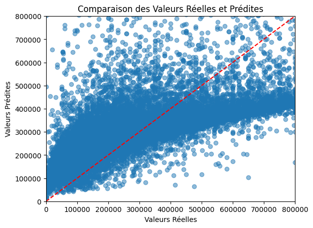

```python
print(f"Mean Squared Error: {mse}")
print(f"R^2 Score: {r2}")
plt.scatter(y_test, y_pred, alpha=0.5)
plt.plot([min(y_test), max(y_test)], [min(y_test), max(y_test)], color='red', linestyle='--')
plt.xlabel('Valeurs Réelles')
plt.ylabel('Valeurs Prédites')
plt.title('Comparaison des Valeurs Réelles et Prédites')

plt.xlim(0, 0.08*10**7)
plt.ylim(0, 0.08*10**7)

plt.show()
```

Notre modèle atteint un coefficient de détermination (R²) qui est d'environ 0.79, ce qui signifie que le modèle explique environ 79.0% de la variance des données. Cela suggère que le modèle de régression linéaire a une performance relativement bonne, mais il reste environ 21% de la variance qui n'est pas expliquée par le modèle.

Le MSE est une mesure de la moyenne des carrés des erreurs, c'est-à-dire la différence entre les valeurs réelles et prédites. Un MSE de 238783577012.80807 indique que les erreurs de prédiction sont élevées en termes absolus, probablement en raison des grandes valeurs de la variable cible (valeur foncière).

La majorité des points bleus sont proches de la ligne rouge en pointillé, ce qui indique que les prédictions du modèle sont généralement proches des valeurs réelles. Cependant, il y a une dispersion notable des points, surtout aux valeurs élevées, ce qui indique des erreurs de prédiction plus importantes pour les valeurs foncières plus élevées.

# Partie Bonus : analyse de 2022

```python
df2022 = pd.read_csv('../valeursfoncieres-2022.txt', sep='|', low_memory=False)
df2022.head(10)
```

|  | Identifiant de document | Reference document | 1 Articles CGI | 2 Articles CGI | 3 Articles CGI | 4 Articles CGI | 5 Articles CGI | No disposition | Date mutation | Nature mutation | ... | Surface Carrez du 5eme lot | Nombre de lots | Code type local | Type local | Identifiant local | Surface reelle bati | Nombre pieces principales | Nature culture | Nature culture speciale | Surface terrain |
| --- | --- | --- | --- | --- | --- | --- | --- | --- | --- | --- | --- | --- | --- | --- | --- | --- | --- | --- | --- | --- | --- |
| 0 | NaN | NaN | NaN | NaN | NaN | NaN | NaN | 1 | 03/01/2022 | Vente | ... | NaN | 1 | 2.0 | Appartement | NaN | 24.0 | 1.0 | NaN | NaN | NaN |
| 1 | NaN | NaN | NaN | NaN | NaN | NaN | NaN | 1 | 03/01/2022 | Vente | ... | NaN | 0 | NaN | NaN | NaN | NaN | NaN | S | NaN | 84.0 |
| 2 | NaN | NaN | NaN | NaN | NaN | NaN | NaN | 1 | 03/01/2022 | Vente | ... | NaN | 0 | NaN | NaN | NaN | NaN | NaN | S | NaN | 88.0 |
| 3 | NaN | NaN | NaN | NaN | NaN | NaN | NaN | 1 | 03/01/2022 | Vente | ... | NaN | 1 | 2.0 | Appartement | NaN | 140.0 | 3.0 | NaN | NaN | NaN |
| 4 | NaN | NaN | NaN | NaN | NaN | NaN | NaN | 1 | 04/01/2022 | Vente | ... | NaN | 0 | NaN | NaN | NaN | NaN | NaN | T | NaN | 510.0 |
| 5 | NaN | NaN | NaN | NaN | NaN | NaN | NaN | 1 | 06/01/2022 | Vente | ... | NaN | 0 | 1.0 | Maison | NaN | 108.0 | 5.0 | S | NaN | 649.0 |
| 6 | NaN | NaN | NaN | NaN | NaN | NaN | NaN | 1 | 06/01/2022 | Vente | ... | NaN | 0 | NaN | NaN | NaN | NaN | NaN | S | NaN | 360.0 |
| 7 | NaN | NaN | NaN | NaN | NaN | NaN | NaN | 1 | 03/01/2022 | Vente | ... | NaN | 0 | NaN | NaN | NaN | NaN | NaN | S | NaN | 50.0 |
| 8 | NaN | NaN | NaN | NaN | NaN | NaN | NaN | 1 | 03/01/2022 | Vente | ... | NaN | 0 | 4.0 | Local industriel. commercial ou assimilé | NaN | 424.0 | 0.0 | S | NaN | 628.0 |
| 9 | NaN | NaN | NaN | NaN | NaN | NaN | NaN | 1 | 03/01/2022 | Vente | ... | NaN | 0 | 2.0 | Appartement | NaN | 126.0 | 4.0 | S | NaN | 628.0 |

10 rows × 43 columns